# YAP1C sulfenome (DIA-NN): specific interactors and their response to high light

Analysis notebook

2026-11-03

# 1 What this notebook does

This is a **YAP1C sulfenome pull-down** in *Arabidopsis thaliana*, measured by data-independent acquisition (DIA) and searched with [DIA-NN](https://github.com/vdemichev/diann#basics-of-dia-data-analysis).

- **YAP1C** carries a reactive cysteine that forms a mixed disulfide with **sulfenylated** (–SOH) cysteines on other proteins, so it traps the oxidised interactome.
- **YAP1A** is the matched negative control (the reactive cysteine is mutated). Anything it pulls down is sticking to the bait for reasons unrelated to sulfenylation, i.e. it is **background**.
- **HL** = high light (oxidative stress), **NL** = normal light (control).

Balanced 2 x 2 design, 4 biological replicates per group, 16 runs:

| Probe (file code) | NL replicates | HL replicates |
| --- | --- | --- |
| YAP1A (`YA`) | runs 1–4 | runs 5–8 |
| YAP1C (`YC`) | runs 13–16 | runs 9–12 |

## 1.1 The four steps

1. **Call interactors.** Keep a protein if, in at least one YAP1C condition, it was identified in **>= 3 of 4 replicates** and supported by **>= 1 peptide(s), at least 1 of them unique** to that protein group.
2. **Decide which of those are specific to the active probe**, using two independent arguments (the two “Step 2” sections below):
   - **Route A — absent from YAP1A.** The protein is never seen with a unique peptide in any control sample.
   - **Route B — enriched over YAP1A.** The protein *is* seen in the control, but is significantly and substantially more abundant with YAP1C (limma, BH-adjusted p < 0.05, log2FC > 1). The **specific interactor set** is the union of the two.
3. **Ask how high light changes the capture of those proteins**, with two complementary tests:
   - **intensity** (limma on log2 MaxLFQ) for proteins quantified in both treatments;
   - **detection** (Fisher’s exact test on replicate counts) which also reaches the on/off proteins that limma cannot test. A coverage check then records which arm reached which protein, and writes out anything neither arm could test.
4. **Merge the two tests into one verdict per protein** and draw the heatmaps.

## 1.2 Version note

Compared with the previous version of this notebook:

- The high-light-vs-normal-light comparison now runs on **both** routes to specificity (route A **and** route B). Previously it used route A only, so every protein that stuck to both probes but stuck much harder to YAP1C was dropped before the HL/NL test.
- Duplicated FDR / fold-change / minimum-replicate settings were collapsed into one of each (`fdr`, `log2fc`, `min_reps`), so the same rule is applied everywhere.
- One heatmap function now serves all four heatmaps; the redundant z-scored heatmap and the two “if this package is missing, do something else” fallbacks were removed.
- A **test coverage** section now audits both arms protein by protein, writes the proteins neither arm could test to their own CSV, and gives them a distinct verdict (`not testable`) instead of filing them under “no clear difference”. Both arms report their coverage split by route, so it is visible that the limma-enriched proteins enter both.
- A stacked bar summarises how much of the broadened set is treatment-specific, overall and per route.
- A **GO enrichment** section tests the broadened set, and the HL- and NL-specific subsets, against the proteins actually detected in this experiment, and draws a term-by-list heatmap.

## 1.3 Glossary

| Term | Plain meaning |
| --- | --- |
| **protein group** | A set of proteins that share the peptides seen, so they cannot be told apart. Written as UniProt accessions joined by `;`. |
| **proteotypic / unique peptide** | A peptide that belongs to only one protein group — unambiguous evidence. |
| **precursor** | One peptide in one charge state; the thing the mass spectrometer actually measures. |
| **q-value / FDR** | The false-discovery rate. 1% means about 1 in 100 accepted identifications is expected to be wrong. |
| **PG.MaxLFQ** | DIA-NN’s protein abundance estimate. Analysed as log2, where +1 means 2-fold higher. |
| **log2FC** | log2 fold-change. 1 = 2-fold up, -1 = 2-fold down. |
| **adjusted p-value** | p-value corrected for testing thousands of proteins (Benjamini-Hochberg). Judge significance on this, not the raw p-value. |
| **limma** | A test that borrows variance information across all proteins, which makes it more reliable than a t-test at n = 4. |
| **NA / grey cell** | Not quantified in that run — either genuinely absent or below the detection limit. Never treated as zero. |

# 2 Packages

```r
# Install anything missing, then load. limma comes from Bioconductor.
cran <- c("dplyr", "tidyr", "tibble", "stringr", "readr", "ggplot2", "ggrepel")
gaps <- cran[!vapply(cran, requireNamespace, logical(1), quietly = TRUE)]
if (length(gaps)) install.packages(gaps, repos = "https://cloud.r-project.org")

if (!requireNamespace("limma", quietly = TRUE)) {
  if (!requireNamespace("BiocManager", quietly = TRUE))
    install.packages("BiocManager", repos = "https://cloud.r-project.org")
  BiocManager::install("limma", update = FALSE, ask = FALSE)
}

suppressPackageStartupMessages({
  library(dplyr); library(tidyr); library(tibble)
  library(stringr); library(readr); library(ggplot2)
})

# report.parquet reader: use arrow if present, otherwise nanoparquet.
read_parquet_any <- function(path) {
  if (requireNamespace("arrow", quietly = TRUE))
    return(as.data.frame(arrow::read_parquet(path)))
  if (!requireNamespace("nanoparquet", quietly = TRUE))
    install.packages("nanoparquet", repos = "https://cloud.r-project.org")
  as.data.frame(nanoparquet::read_parquet(path))
}

# Ensembl Plants connection, used for peptide IDs and for GO terms. Both results
# are cached to disk, so this only runs on the first knit.
plants_mart <- function() {
  if (!requireNamespace("biomaRt", quietly = TRUE)) {
    if (!requireNamespace("BiocManager", quietly = TRUE))
      install.packages("BiocManager", repos = "https://cloud.r-project.org")
    BiocManager::install("biomaRt", update = FALSE, ask = FALSE)
  }
  biomaRt::useDataset(dataset = params$mart_dataset,
                      mart    = biomaRt::useMart(biomart = "plants_mart",
                                                 host = params$mart_host))
}

dir.create(params$outdir, showWarnings = FALSE, recursive = TRUE)
```

# 3 Sample sheet

```r
# Which raw file is which probe and which light condition.
design <- read_tsv(params$design, show_col_types = FALSE)
stopifnot(all(c("Run", "Genotype", "Treatment") %in% names(design)))

design <- design %>%
  mutate(Genotype  = factor(recode(Genotype, YA = "YAP1A", YC = "YAP1C"),
                            levels = c("YAP1A", "YAP1C")),
         Treatment = factor(Treatment, levels = c("NL", "HL")),
         Group     = paste(Genotype, Treatment, sep = "_")) %>%
  arrange(Genotype, Treatment, Run)     # this order is reused by every heatmap

design
```

| Run | Genotype | Treatment | Group |
| --- | --- | --- | --- |
| NUCLEOX1271_1 | YAP1A | NL | YAP1A_NL |
| NUCLEOX1271_2 | YAP1A | NL | YAP1A_NL |
| NUCLEOX1271_3 | YAP1A | NL | YAP1A_NL |
| NUCLEOX1271_4 | YAP1A | NL | YAP1A_NL |
| NUCLEOX1271_5 | YAP1A | HL | YAP1A_HL |
| NUCLEOX1271_6 | YAP1A | HL | YAP1A_HL |
| NUCLEOX1271_7 | YAP1A | HL | YAP1A_HL |
| NUCLEOX1271_8 | YAP1A | HL | YAP1A_HL |
| NUCLEOX1271_13 | YAP1C | NL | YAP1C_NL |
| NUCLEOX1271_14 | YAP1C | NL | YAP1C_NL |

[output cut: 6 more lines]

```r
table(design$Genotype, design$Treatment)
```

```
##
##         NL HL
##   YAP1A  4  4
##   YAP1C  4  4
```

# 4 DIA-NN report: load and apply the confidence filters

`report.parquet` is the long precursor-level table: one row per precursor per run. We keep only target precursors that pass the 1% FDR cut-offs and carry a positive quantity.

```r
rep_raw <- read_parquet_any(params$parquet)
cat("Raw report:", nrow(rep_raw), "rows x", ncol(rep_raw), "columns\n")
```

```
## Raw report: 277609 rows x 71 columns
```

```r
stopifnot(all(c("Run", "Protein.Group", "Stripped.Sequence", "Proteotypic",
                "Q.Value", "PG.Q.Value", "PG.MaxLFQ",
                "Precursor.Quantity") %in% names(rep_raw)))

rep <- rep_raw
if ("Decoy" %in% names(rep))          rep <- filter(rep, Decoy == 0)
rep <- filter(rep, Q.Value    <= params$q_value,
                   PG.Q.Value <= params$pg_q_value,
                   Precursor.Quantity > 0)
if ("Global.Q.Value" %in% names(rep)) rep <- filter(rep, Global.Q.Value <= params$global_q)

rep <- inner_join(rep, design, by = "Run")

cat("Confident rows kept:", nrow(rep), "\n")
```

```
## Confident rows kept: 264913
```

```r
cat("Runs found:", n_distinct(rep$Run), "of", nrow(design), "\n")
```

```
## Runs found: 16 of 16
```

```r
cat("Protein groups:", n_distinct(rep$Protein.Group), "\n")
```

```
## Protein groups: 5170
```

## 4.1 Identification QC

Each bar is one run. Bars of very different height within a group point to a weak injection or an unequal pull-down, which is worth knowing before interpreting any statistics.

```r
qc <- rep %>%
  group_by(Run, Group) %>%
  summarise(precursors     = n_distinct(Precursor.Id),
            peptides       = n_distinct(Stripped.Sequence),
            protein_groups = n_distinct(Protein.Group), .groups = "drop") %>%
  arrange(Group, Run)
qc
```

| Run | Group | precursors | peptides | protein_groups |
| --- | --- | --- | --- | --- |
| NUCLEOX1271_5 | YAP1A_HL | 15040 | 14219 | 3429 |
| NUCLEOX1271_6 | YAP1A_HL | 17664 | 16402 | 3706 |
| NUCLEOX1271_7 | YAP1A_HL | 14593 | 13589 | 3279 |
| NUCLEOX1271_8 | YAP1A_HL | 12204 | 11507 | 2858 |
| NUCLEOX1271_1 | YAP1A_NL | 13773 | 13062 | 3240 |
| NUCLEOX1271_2 | YAP1A_NL | 11710 | 11102 | 2812 |
| NUCLEOX1271_3 | YAP1A_NL | 16947 | 16056 | 3768 |
| NUCLEOX1271_4 | YAP1A_NL | 16450 | 15344 | 3660 |
| NUCLEOX1271_10 | YAP1C_HL | 18190 | 17055 | 3965 |
| NUCLEOX1271_11 | YAP1C_HL | 19801 | 18528 | 4200 |

[output cut: 6 more lines]

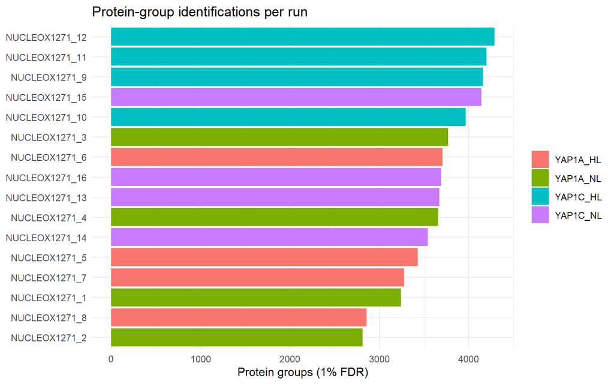

```r
ggplot(qc, aes(reorder(Run, protein_groups), protein_groups, fill = Group)) +
  geom_col() + coord_flip() +
  labs(x = NULL, y = "Protein groups (1% FDR)", fill = NULL,
       title = "Protein-group identifications per run") +
  theme_minimal()
```

# 5 How much evidence supports each protein, in each condition

For every protein group, in each probe x light condition, count: how many replicates saw it, how many distinct peptides support it, and how many of those peptides are unique to it.

```r
evidence <- rep %>%
  group_by(Protein.Group, Genotype, Treatment) %>%
  summarise(n_reps_detected        = n_distinct(Run),
            n_peptides             = n_distinct(Stripped.Sequence),
            n_proteotypic_peptides = n_distinct(Stripped.Sequence[Proteotypic == 1]),
            .groups = "drop")

# Same information one protein per row, for the exported tables.
evidence_wide <- evidence %>%
  pivot_wider(id_cols = Protein.Group,
              names_from  = c(Genotype, Treatment),
              values_from = c(n_reps_detected, n_peptides, n_proteotypic_peptides),
              values_fill = 0)
head(evidence_wide)
```

| Protein.Group | n_reps_detected_YAP1A_HL | n_reps_detected_YAP1C_HL | n_reps_detected_YAP1C_NL | n_reps_detected_YAP1A_NL | n_peptides_YAP1A_HL | n_peptides_YAP1C_HL | n_peptides_YAP1C_NL | n_peptides_YAP1A_NL | n_proteotypic_peptides_YAP1A_HL | n_proteotypic_peptides_YAP1C_HL | n_proteotypic_peptides_YAP1C_NL | n_proteotypic_peptides_YAP1A_NL |
| --- | --- | --- | --- | --- | --- | --- | --- | --- | --- | --- | --- | --- |
| A0A178UVJ1;A0A1P8B6W7;Q8W4C4 | 1 | 1 | 0 | 0 | 1 | 1 | 0 | 0 | 1 | 1 | 0 | 0 |
| A0A178UXH8;A0A1P8B5Z2;B9DFI3;F4JS39;Q9SZE9 | 0 | 1 | 0 | 0 | 0 | 1 | 0 | 0 | 0 | 1 | 0 | 0 |
| A0A178V841;A0A1I9LRS5;F4J5R1 | 0 | 1 | 0 | 0 | 0 | 1 | 0 | 0 | 0 | 1 | 0 | 0 |
| A0A178V9X6;A0A1I9LR49;Q0WPD9;F4J7E1 | 0 | 1 | 1 | 0 | 0 | 1 | 1 | 0 | 0 | 1 | 1 | 0 |
| A0A178VI87;A0A1I9LNU0;A4IJ32 | 4 | 4 | 4 | 2 | 1 | 1 | 1 | 1 | 1 | 1 | 1 | 1 |
| A0A178VNS0;A0A1I9LR61;F4JET6 | 4 | 4 | 4 | 4 | 3 | 3 | 3 | 3 | 0 | 0 | 0 | 0 |

# 6 Ensembl peptide IDs and protein annotation

Protein groups are keyed by UniProt accession, which is hard to read at the bench. Here we attach an `ensembl_peptide_id` (AGI-style, e.g. `AT3G14630.2`) to every group so all lists and figures can be read in TAIR/Ensembl terms. Where a group carries several accessions (`A0A1I9LTL1;F4IW82`), each is translated in place and re-joined in the same order (`AT3G14630.2;AT3G14630.1`).

IDs come from **Ensembl Plants** via **biomaRt** (`athaliana_eg_gene`, filter `uniprotkb_all`, attribute `ensembl_peptide_id`) and are cached in `output_batch1/results/uniprot_to_ensembl_peptide.csv` so later knits do not query the server again. If Ensembl is unreachable, or an accession has no mapped peptide, that position falls back to the UniProt accession — no row is ever left blank.

```r
pg_all    <- unique(rep$Protein.Group)
acc_by_pg <- str_split(pg_all, ";")            # accessions per group, order kept
all_acc   <- unique(unlist(acc_by_pg))
all_acc   <- all_acc[nzchar(all_acc)]

cache_path <- file.path(params$outdir, params$pep_id_cache)
if (file.exists(cache_path)) {
  u2p <- read_csv(cache_path, show_col_types = FALSE)
} else {
  u2p <- tryCatch({
    biomaRt::getBM(attributes = c("uniprotkb_all", "ensembl_peptide_id"),
                   filters    = "uniprotkb_all",
                   values     = all_acc,
                   mart       = plants_mart()) %>%
      filter(nzchar(uniprotkb_all), nzchar(ensembl_peptide_id))
  }, error = function(e) {
    cat("!! biomaRt query failed:", conditionMessage(e),
        "\n   peptide IDs will fall back to UniProt accessions.\n")
    tibble(uniprotkb_all = character(), ensembl_peptide_id = character())
  })
  if (nrow(u2p)) write_csv(u2p, cache_path)
}

# One representative peptide ID per accession -> fast lookup table.
lut <- u2p %>%
  filter(nzchar(ensembl_peptide_id)) %>%
  group_by(uniprotkb_all) %>%
  summarise(pep = first(ensembl_peptide_id), .groups = "drop") %>%
  { setNames(.$pep, .$uniprotkb_all) }

pg_pep_map <- tibble(
  Protein.Group = pg_all,
  ensembl_peptide_id = vapply(acc_by_pg, function(accs) {
    pep <- unname(lut[accs])
    gap <- is.na(pep) | !nzchar(pep)
    pep[gap] <- accs[gap]                      # fall back to the accession
    paste(pep, collapse = ";")
  }, character(1)))

# pep_label() is used by every figure that needs a readable protein label.
pg2pep    <- setNames(pg_pep_map$ensembl_peptide_id, pg_pep_map$Protein.Group)
pep_label <- function(pg) {
  out <- unname(pg2pep[pg])
  gap <- is.na(out) | !nzchar(out)
  out[gap] <- sub(";.*$", "", pg[gap])         # leading UniProt accession
  out
}

cat(sprintf("Mapped %d/%d accessions; %d/%d protein groups fully mapped.\n",
            sum(all_acc %in% names(lut)), length(all_acc),
            sum(vapply(acc_by_pg, function(a) all(a %in% names(lut)), logical(1))),
            length(pg_all)))
```

```
## Mapped 5806/5867 accessions; 5109/5170 protein groups fully mapped.
```

```r
head(pg_pep_map, 10)
```

| Protein.Group | ensembl_peptide_id |
| --- | --- |
| F4I420 | AT1G76810.1 |
| Q8L5R3 | AT3G60740.1 |
| P25873 | AT3G25920.1 |
| Q9ZSR7 | AT5G46110.1 |
| O50008 | AT5G17920.1 |
| Q9SV09 | AT3G51950.4 |
| F4I0K2 | AT1G69200.1 |
| Q9SQI2 | AT1G22770.1 |
| Q9ZRT5 | AT5G41210.1 |
| Q9ZVW2 | AT2G06990.1 |

```r
# One annotation row per protein group. This matters: the same group can carry
# slightly different Genes/Protein.Names strings in different runs, and if we
# kept all of them every later join would silently duplicate rows.
annot <- rep %>%
  group_by(Protein.Group) %>%
  summarise(Protein.Ids   = first(Protein.Ids),
            Protein.Names = first(Protein.Names),
            Genes         = first(Genes), .groups = "drop") %>%
  left_join(pg_pep_map, by = "Protein.Group")

if (file.exists(params$prot_desc)) {
  pd <- read_tsv(params$prot_desc, show_col_types = FALSE) %>%
    group_by(Protein.Id) %>%
    summarise(Description = first(Description), .groups = "drop")
  annot <- annot %>%
    mutate(.first = str_split_fixed(Protein.Ids, ";", 2)[, 1]) %>%
    left_join(pd, by = c(".first" = "Protein.Id")) %>%
    select(-.first)
}

stopifnot(!anyDuplicated(annot$Protein.Group))   # guard: exactly one row per group
```

# 7 Step 1: call YAP1C interactors

A protein group is an **interactor** if, in at least one YAP1C condition (NL or HL), it was detected in >= 3/4 replicates and supported by >= 1 distinct peptide(s), of which at least 1 is unique to the group.

> With the current settings this is the rule *“at least one unique peptide, reproducibly in 3 of 4 replicates”*. If you want the stricter two-peptide rule, set `min_peptides: 2` in the header — nothing else needs to change.

```r
yc_qual <- evidence %>%
  filter(Genotype == "YAP1C") %>%
  mutate(passes = n_reps_detected        >= params$min_reps &
                  n_peptides             >= params$min_peptides &
                  n_proteotypic_peptides >= params$min_proteotypic) %>%
  select(Protein.Group, Treatment, passes) %>%
  pivot_wider(names_from = Treatment, values_from = passes, values_fill = FALSE)

yc_interactors <- yc_qual %>%
  filter(HL | NL) %>%
  mutate(qualifies_in = case_when(HL & NL ~ "both", HL ~ "HL", TRUE ~ "NL"))

cat("YAP1C interactors:", nrow(yc_interactors), "\n")
```

```
## YAP1C interactors: 3624
```

```r
table(yc_interactors$qualifies_in)
```

```
##
## both   HL   NL
## 3026  502   96
```

# 8 Step 2, route A: proteins absent from YAP1A

Any protein group with **>= 1 unique peptide in any YAP1A sample** is called background. This is deliberately strict — a single unique peptide in one control run is enough to disqualify a protein — so route A on its own is conservative and will discard real targets that also bind the control weakly. Route B (next section) is what recovers them.

```r
ya_background <- rep %>%
  filter(Genotype == "YAP1A", Proteotypic == 1) %>%
  distinct(Protein.Group) %>% pull(Protein.Group)

absent_in_YA <- yc_interactors %>% filter(!Protein.Group %in% ya_background)

cat("YAP1A background groups (>=1 unique peptide in a control run):",
    length(ya_background), "\n")
```

```
## YAP1A background groups (>=1 unique peptide in a control run): 3996
```

```r
cat("Route A - interactors absent from YAP1A:", nrow(absent_in_YA), "\n")
```

```
## Route A - interactors absent from YAP1A: 184
```

```r
write_csv(absent_in_YA %>% left_join(annot, by = "Protein.Group") %>%
            left_join(evidence_wide, by = "Protein.Group") %>% arrange(Genes),
          file.path(params$outdir, "unique_YAP1C_interactors.csv"))
write_csv(tibble(Protein.Group = ya_background) %>% left_join(annot, by = "Protein.Group"),
          file.path(params$outdir, "YAP1A_background_list.csv"))
write_csv(yc_interactors %>% left_join(annot, by = "Protein.Group"),
          file.path(params$outdir, "YAP1C_all_interactors.csv"))

tibble(step = c("Protein groups in the filtered report",
                "YAP1C interactors",
                "of which also in YAP1A background",
                "Route A: absent from YAP1A"),
       n = c(n_distinct(rep$Protein.Group),
             nrow(yc_interactors),
             sum(yc_interactors$Protein.Group %in% ya_background),
             nrow(absent_in_YA)))
```

| step | n |
| --- | --- |
| Protein groups in the filtered report | 5170 |
| YAP1C interactors | 3624 |
| of which also in YAP1A background | 3440 |
| Route A: absent from YAP1A | 184 |

# 9 Step 2, route B: proteins enriched in YAP1C over YAP1A

Here we keep the proteins route A throws away, and ask a quantitative question instead: *is this protein pulled down substantially more by the active probe than by the control?*

**Intensity table.** One log2 `PG.MaxLFQ` value per protein per run, all 16 samples. (MaxLFQ is constant across the precursors of a group within a run, so one value per Run x Protein.Group defines the matrix.)

```r
pg_long <- rep %>%
  distinct(Run, Protein.Group, PG.MaxLFQ) %>%
  filter(!is.na(PG.MaxLFQ), PG.MaxLFQ > 0)
stopifnot(!anyDuplicated(pg_long[c("Run", "Protein.Group")]))   # one value per cell

log2_all <- pg_long %>%
  pivot_wider(names_from = Run, values_from = PG.MaxLFQ) %>%
  column_to_rownames("Protein.Group") %>%
  as.matrix() %>% log2()
# columns in a fixed, readable order: YAP1A NL, YAP1A HL, YAP1C NL, YAP1C HL
log2_all <- log2_all[, design$Run[design$Run %in% colnames(log2_all)], drop = FALSE]

meta <- design %>% filter(Run %in% colnames(log2_all)) %>%
  arrange(match(Run, colnames(log2_all)))

cat("Full matrix:", nrow(log2_all), "proteins x", ncol(log2_all), "runs",
    sprintf("(%d YAP1A, %d YAP1C)\n",
            sum(meta$Genotype == "YAP1A"), sum(meta$Genotype == "YAP1C")))
```

```
## Full matrix: 5170 proteins x 16 runs (8 YAP1A, 8 YAP1C)
```

```r
# One function draws every heatmap in this notebook.
#   pg    : protein groups to show, first one at the top
#   mat   : log2 intensity matrix (log2_all = 16 samples, log2mat = 8 YAP1C samples)
#   facet : how to split the columns ("Treatment", or "Genotype + Treatment")
# Missing values stay grey - they are never filled in for plotting.
lfq_heatmap <- function(pg, mat, facet = "Treatment", title = NULL, subtitle = NULL,
                        max_rows_labelled = 80) {
  pg <- unique(pg[pg %in% rownames(mat)])
  if (!length(pg)) { cat("Nothing to plot for:", title, "\n"); return(invisible(NULL)) }
  # optional = TRUE keeps the run names exactly as they are in the matrix
  df <- as.data.frame(mat[pg, , drop = FALSE], optional = TRUE) %>%
    rownames_to_column("Protein.Group") %>%
    pivot_longer(-Protein.Group, names_to = "Run", values_to = "log2LFQ") %>%
    left_join(select(design, Run, Genotype, Treatment), by = "Run") %>%
    mutate(Run = factor(Run, levels = colnames(mat)),
           Protein.Group = factor(Protein.Group, levels = rev(pg)))
  ggplot(df, aes(Run, Protein.Group, fill = log2LFQ)) +
    geom_tile(colour = "grey92") +
    facet_grid(as.formula(paste(". ~", facet)), scales = "free_x", space = "free_x") +
    scale_fill_viridis_c(option = "C", na.value = "grey88",
                         name = "log2 LFQ\n(PG.MaxLFQ)") +
    scale_y_discrete(labels = setNames(pep_label(pg), pg)) +
    labs(title = title, subtitle = subtitle, x = NULL, y = NULL) +
    theme_minimal(base_size = 9) +
    theme(axis.text.x  = element_text(angle = 45, hjust = 1),
          axis.text.y  = if (length(pg) <= max_rows_labelled) element_text(size = 6)
                         else element_blank(),
          panel.grid   = element_blank(),
          strip.text   = element_text(size = 8))
}

# Sort protein groups by how much stronger they are in HL than in NL, biggest first.
order_by_hl_minus_nl <- function(pg, mat, hl_runs, nl_runs) {
  pg <- unique(pg[pg %in% rownames(mat)])
  d  <- rowMeans(mat[pg, hl_runs, drop = FALSE], na.rm = TRUE) -
        rowMeans(mat[pg, nl_runs, drop = FALSE], na.rm = TRUE)
  pg[order(d, decreasing = TRUE, na.last = TRUE)]
}

# Sort by mean log2 LFQ across only the runs where the protein was detected
# (na.rm drops the blanks), most abundant first. Use this rather than HL - NL
# whenever a set contains treatment-exclusive proteins: one of their two means
# is taken over nothing at all, so the difference is undefined and they would
# otherwise be dumped at the bottom of the plot in arbitrary order.
order_by_mean_lfq <- function(pg, mat) {
  pg <- unique(pg[pg %in% rownames(mat)])
  if (!length(pg)) return(pg)
  m <- rowMeans(mat[pg, , drop = FALSE], na.rm = TRUE)
  pg[order(m, decreasing = TRUE, na.last = TRUE)]
}
```

**Missing values.** The 16 samples form four groups of four replicates (YAP1A_NL, YAP1A_HL, YAP1C_NL, YAP1C_HL). Within a group, a protein counts as **valid** if it was quantified in >= 3 of the 4 replicates; missing cells in a valid group are filled with the mean of the replicates that *were* observed. Groups that fail the 3/4 rule are left empty and are **not** invented — limma simply ignores those samples for that protein.

```r
# Which columns belong to each of the four replicate groups.
group_cols <- split(seq_len(nrow(meta)), meta$Group)

# valid[protein, group] = TRUE if that group observed the protein >= min_reps times.
valid <- sapply(group_cols, function(cols)
  rowSums(!is.na(log2_all[, cols, drop = FALSE])) >= params$min_reps)

# Fill the gaps inside valid groups with that group's observed mean.
Xe <- log2_all
for (g in colnames(valid)) {
  cols <- group_cols[[g]]
  gmean <- rowMeans(log2_all[, cols, drop = FALSE], na.rm = TRUE)
  for (j in cols) {
    hole <- is.na(Xe[, j]) & valid[, g]
    Xe[hole, j] <- gmean[hole]
  }
}

# Only proteins seen properly in BOTH probes can be compared between probes.
seen_in_YA <- rowSums(valid[, grep("^YAP1A", colnames(valid)), drop = FALSE]) > 0
seen_in_YC <- rowSums(valid[, grep("^YAP1C", colnames(valid)), drop = FALSE]) > 0
Xe <- Xe[seen_in_YA & seen_in_YC, , drop = FALSE]

cat("Proteins testable for YAP1C vs YAP1A (valid in >=", params$min_reps,
    "/4 of a group in both probes):", nrow(Xe), "\n")
```

```
## Proteins testable for YAP1C vs YAP1A (valid in >= 3 /4 of a group in both probes): 3212
```

**The test.** limma with the design `~ 0 + Genotype` and the contrast **YAP1C - YAP1A**; variance is stabilised across proteins with empirical Bayes and p-values corrected by Benjamini-Hochberg. Light condition is pooled here, since the question is about the probe, not the light (to model light as well, use `~ 0 + Genotype + Treatment`). Proteins with adjusted p < 0.05 **and** log2FC > 1 are the route B set.

```r
des_g <- model.matrix(~ 0 + Genotype, data = meta)
fit   <- limma::lmFit(Xe, des_g)
fit   <- limma::contrasts.fit(
  fit, limma::makeContrasts(GenotypeYAP1C - GenotypeYAP1A, levels = des_g))
fit   <- limma::eBayes(fit)

enr <- limma::topTable(fit, number = Inf, sort.by = "none") %>%
  rownames_to_column("Protein.Group") %>%
  transmute(Protein.Group, log2FC_YC_vs_YA = logFC, AveExpr, t,
            pvalue = P.Value, adj_pvalue = adj.P.Val) %>%
  mutate(class = case_when(
    adj_pvalue < params$fdr & log2FC_YC_vs_YA >  params$log2fc ~ "enriched in YAP1C",
    adj_pvalue < params$fdr & log2FC_YC_vs_YA <  0             ~ "enriched in YAP1A",
    TRUE                                                       ~ "ns")) %>%
  arrange(adj_pvalue)

enriched_in_YC <- filter(enr, class == "enriched in YAP1C")

write_csv(enr %>% left_join(annot, by = "Protein.Group"),
          file.path(params$outdir, "YAP1C_vs_YAP1A_limma.csv"))
write_csv(enriched_in_YC %>% left_join(annot, by = "Protein.Group"),
          file.path(params$outdir, "YAP1C_enriched_significant.csv"))

cat(sprintf("Route B - enriched in YAP1C (adj.p < %.2g & log2FC > %g): %d\n",
            params$fdr, params$log2fc, nrow(enriched_in_YC)))
```

```
## Route B - enriched in YAP1C (adj.p < 0.05 & log2FC > 1): 38
```

```r
enriched_in_YC %>%
  transmute(uniprot = Protein.Group, peptide_id = pep_label(Protein.Group),
            log2FC_YC_vs_YA, adj_pvalue) %>% head(25)
```

|  | uniprot | peptide_id | log2FC_YC_vs_YA | adj_pvalue |
| --- | --- | --- | --- | --- |
| 1 | Q9C505 | AT1G69410.1 | 2.412683 | 1.535244e-10 |
| 2 | Q9FJY1 | AT5G66590.1 | 2.851051 | 9.055218e-10 |
| 3 | O65719 | AT3G09440.3 | 1.708837 | 3.146607e-09 |
| 4 | P41916;P41917;Q8H156 | AT5G20010.1;AT5G20020.1;AT5G55190.1 | 1.983665 | 2.413686e-08 |
| 5 | Q9C891 | AT1G55210.2 | 1.364141 | 3.427076e-08 |
| 6 | F4IZR5 | AT3G03110.1 | 1.403613 | 3.427076e-08 |
| 7 | P32826 | AT3G10410.1 | 1.616252 | 3.495017e-08 |
| 8 | P22953 | AT5G02500.1 | 1.726282 | 4.639619e-08 |
| 9 | P35510 | AT2G37040.1 | 2.801195 | 5.408486e-08 |
| 10 | P45724 | AT3G53260.1 | 2.236081 | 6.625320e-08 |

[output cut: 15 more lines]

## 9.1 Volcano: YAP1C vs YAP1A

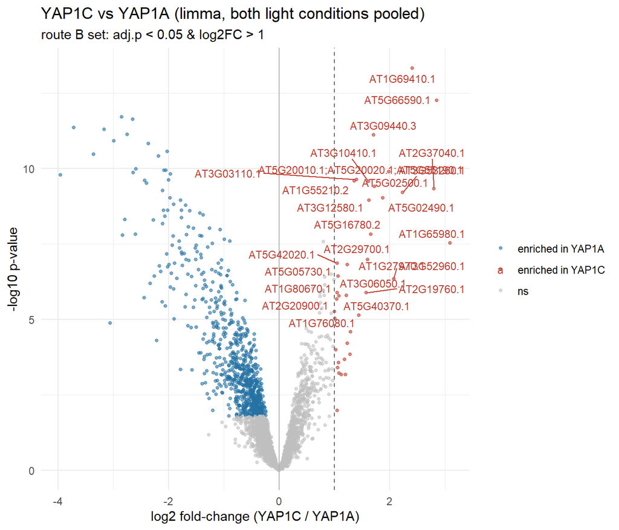

```r
ggplot(enr, aes(log2FC_YC_vs_YA, -log10(pvalue), colour = class)) +
  geom_point(alpha = 0.6, size = 1) +
  geom_vline(xintercept = 0, colour = "grey70") +
  geom_vline(xintercept = params$log2fc, linetype = "dashed", colour = "grey40") +
  ggrepel::geom_text_repel(data = head(enriched_in_YC, 25),
                           aes(label = pep_label(Protein.Group)),
                           size = 3, max.overlaps = 20) +
  scale_colour_manual(values = c("enriched in YAP1C" = "#c0392b",
                                 "enriched in YAP1A" = "#2471a3",
                                 "ns" = "grey75")) +
  labs(title = "YAP1C vs YAP1A (limma, both light conditions pooled)",
       subtitle = sprintf("route B set: adj.p < %.2g & log2FC > %g",
                          params$fdr, params$log2fc),
       x = "log2 fold-change (YAP1C / YAP1A)", y = "-log10 p-value", colour = NULL) +
  theme_minimal()
```

## 9.2 The strongest route B proteins across all 16 samples

Both contrasts read at once: **YAP1C vs YAP1A** across the probe panels, **NL vs HL** within each probe.

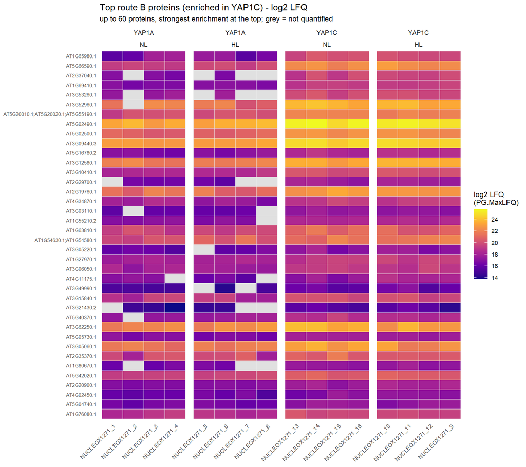

```r
top_enriched <- head(enriched_in_YC$Protein.Group[
  order(enriched_in_YC$log2FC_YC_vs_YA, decreasing = TRUE)], 60)

lfq_heatmap(top_enriched, mat = log2_all, facet = "Genotype + Treatment",
            title = "Top route B proteins (enriched in YAP1C) - log2 LFQ",
            subtitle = "up to 60 proteins, strongest enrichment at the top; grey = not quantified")
```

# 10 Step 2, combined: the specific interactor set carried forward

**This union is the set used by every HL-vs-NL analysis below.**

```r
specific <- annot %>%
  filter(Protein.Group %in% union(absent_in_YA$Protein.Group,
                                  enriched_in_YC$Protein.Group)) %>%
  mutate(in_A = Protein.Group %in% absent_in_YA$Protein.Group,
         in_B = Protein.Group %in% enriched_in_YC$Protein.Group,
         route = case_when(in_A & in_B ~ "both routes",
                           in_A        ~ "A: absent from YAP1A",
                           TRUE        ~ "B: enriched over YAP1A")) %>%
  select(-in_A, -in_B) %>%
  left_join(select(yc_interactors, Protein.Group, qualifies_in), by = "Protein.Group") %>%
  # Route B proteins were selected on abundance alone; this flags whether they
  # also clear the step-1 evidence bar (>= min_reps replicates + unique peptide).
  mutate(passes_step1 = !is.na(qualifies_in))

if (!isTRUE(params$include_enriched))
  specific <- filter(specific, route != "B: enriched over YAP1A")

write_csv(specific, file.path(params$outdir, "YAP1C_specific_interactors_broadened.csv"))

cat("Specific interactors carried into the HL vs NL analysis:", nrow(specific), "\n")
```

```
## Specific interactors carried into the HL vs NL analysis: 222
```

```r
print(table(specific$route))
```

```
##
##   A: absent from YAP1A B: enriched over YAP1A
##                    184                     38
```

```r
cat("\nOf these, how many also pass the step-1 evidence rule:\n")
```

```
##
## Of these, how many also pass the step-1 evidence rule:
```

```r
print(table(route = specific$route, passes_step1 = specific$passes_step1))
```

```
##                         passes_step1
## route                    FALSE TRUE
##   A: absent from YAP1A       0  184
##   B: enriched over YAP1A     4   34
```

# 11 Intensity table for the YAP1C samples

The eight YAP1C runs, restricted to the specific interactors. This is a straight subset of the 16-sample matrix built above, so the two halves of the notebook cannot drift apart.

```r
yc_meta <- filter(meta, Genotype == "YAP1C")
yc_runs <- yc_meta$Run                                   # NL block, then HL block
hl_runs <- yc_meta$Run[yc_meta$Treatment == "HL"]
nl_runs <- yc_meta$Run[yc_meta$Treatment == "NL"]

log2mat <- log2_all[intersect(specific$Protein.Group, rownames(log2_all)), yc_runs,
                    drop = FALSE]
log2mat <- log2mat[rowSums(!is.na(log2mat)) > 0, , drop = FALSE]

cat("HL vs NL matrix:", nrow(log2mat), "proteins x", ncol(log2mat), "YAP1C runs\n")
```

```
## HL vs NL matrix: 222 proteins x 8 YAP1C runs
```

```r
cat("Specific interactors with no MaxLFQ value in any YAP1C run (not plottable):",
    nrow(specific) - nrow(log2mat), "\n")
```

```
## Specific interactors with no MaxLFQ value in any YAP1C run (not plottable): 0
```

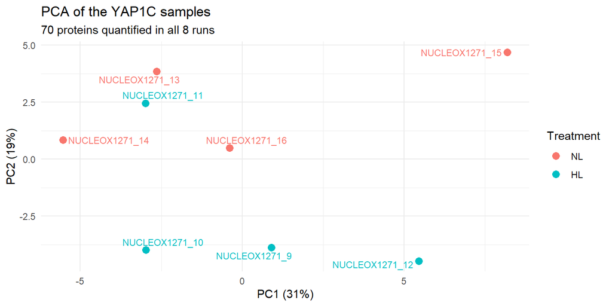

```r
# Sanity check: do the replicates separate by light condition?
ok <- log2mat[rowSums(is.na(log2mat)) == 0, , drop = FALSE]
ok <- ok[rowSums((ok - rowMeans(ok))^2) > 0, , drop = FALSE]   # drop flat rows
if (nrow(ok) > 2) {
  pca <- prcomp(t(ok), scale. = TRUE)
  ve  <- round(100 * summary(pca)$importance[2, 1:2])
  as.data.frame(pca$x[, 1:2]) %>% rownames_to_column("Run") %>%
    left_join(select(design, Run, Treatment), by = "Run") %>%
    ggplot(aes(PC1, PC2, colour = Treatment, label = Run)) +
      geom_point(size = 3) +
      ggrepel::geom_text_repel(size = 3, show.legend = FALSE) +
      labs(title = "PCA of the YAP1C samples",
           subtitle = sprintf("%d proteins quantified in all 8 runs", nrow(ok)),
           x = paste0("PC1 (", ve[1], "%)"), y = paste0("PC2 (", ve[2], "%)")) +
      theme_minimal()
} else cat("Too few complete-case proteins for a PCA.\n")
```

# 12 Step 3, arm 1: HL vs NL by intensity (limma)

This arm asks *“is the protein captured more strongly?”*, so it needs numbers in both treatments: we test only proteins with >= 3 quantified values **in each** YAP1C group. Proteins present in essentially one treatment cannot be tested here — they are picked up by arm 2, so nothing is quietly lost.

```r
n_HL <- rowSums(!is.na(log2mat[, hl_runs, drop = FALSE]))
n_NL <- rowSums(!is.na(log2mat[, nl_runs, drop = FALSE]))
X <- log2mat[n_HL >= params$min_reps & n_NL >= params$min_reps, , drop = FALSE]

# Fill the few remaining gaps with that treatment's observed mean (every row
# here already has at least min_reps real values per treatment).
for (cols in list(hl_runs, nl_runs)) {
  m <- rowMeans(X[, cols, drop = FALSE], na.rm = TRUE)
  for (j in cols) { hole <- is.na(X[, j]); X[hole, j] <- m[hole] }
}

cat("Testable by intensity:", nrow(X), "of", nrow(log2mat), "specific interactors\n")
```

```
## Testable by intensity: 99 of 222 specific interactors
```

```r
# Broken down by how each protein earned its place in the specific set, so it is
# visible that route B (limma-enriched) proteins enter this arm too.
print(table(route  = specific$route[match(rownames(log2mat), specific$Protein.Group)],
            fitted = ifelse(rownames(log2mat) %in% rownames(X), "yes", "no")))
```

```
##                         fitted
## route                     no yes
##   A: absent from YAP1A   123  61
##   B: enriched over YAP1A   0  38
```

```r
trt <- yc_meta$Treatment[match(colnames(X), yc_meta$Run)]   # NL / HL, one per column
des <- model.matrix(~ 0 + trt)
colnames(des) <- sub("^trt", "", colnames(des))             # -> "NL", "HL"

fit <- limma::lmFit(X, des)
fit <- limma::contrasts.fit(fit, limma::makeContrasts(HL - NL, levels = des))
fit <- limma::eBayes(fit)

de <- limma::topTable(fit, number = Inf, sort.by = "none") %>%
  rownames_to_column("Protein.Group") %>%
  transmute(Protein.Group, log2FC_HL_vs_NL = logFC, AveExpr, t,
            pvalue = P.Value, adj_pvalue = adj.P.Val) %>%
  mutate(direction = case_when(
    adj_pvalue < params$fdr & log2FC_HL_vs_NL >=  params$log2fc ~ "up in HL",
    adj_pvalue < params$fdr & log2FC_HL_vs_NL <= -params$log2fc ~ "down in HL",
    TRUE                                                        ~ "ns")) %>%
  arrange(adj_pvalue)

write_csv(de %>% left_join(specific, by = "Protein.Group"),
          file.path(params$outdir, "YAP1C_NL_vs_HL_differential.csv"))

cat(sprintf("Significant (adj.p < %.2g & |log2FC| >= %g): %d  (up in HL = %d, down = %d)\n",
            params$fdr, params$log2fc, sum(de$direction != "ns"),
            sum(de$direction == "up in HL"), sum(de$direction == "down in HL")))
```

```
## Significant (adj.p < 0.05 & |log2FC| >= 1): 0  (up in HL = 0, down = 0)
```

```r
de %>% left_join(select(specific, Protein.Group, Genes, route), by = "Protein.Group") %>%
  head(20)
```

|  | Protein.Group | log2FC_HL_vs_NL | AveExpr | t | pvalue | adj_pvalue | direction | Genes | route |
| --- | --- | --- | --- | --- | --- | --- | --- | --- | --- |
| 1 | O49304 | -0.9527968 | 12.92495 | -3.514056 | 0.002767121 | 0.09131501 | ns | At1g23130 | A: absent from YAP1A |
| 2 | O82499 | 1.0420802 | 17.84154 | 3.615406 | 0.002227360 | 0.09131501 | ns | At4g11175 | B: enriched over YAP1A |
| 3 | Q39027 | -0.9707129 | 16.17442 | -3.811993 | 0.001462125 | 0.09131501 | ns | MPK7 | A: absent from YAP1A |
| 4 | O23401 | -0.6763876 | 13.51736 | -2.743385 | 0.014140135 | 0.26011643 | ns | UGT84A3 | A: absent from YAP1A |
| 5 | O23708 | -0.8047928 | 17.39419 | -2.716527 | 0.014949630 | 0.26011643 | ns | PAB1 | A: absent from YAP1A |
| 6 | P59233 | -0.7677050 | 23.27975 | -2.641090 | 0.017468423 | 0.26011643 | ns | RPS27AC | B: enriched over YAP1A |
| 7 | Q9FFP6 | -0.6021192 | 16.53301 | -2.616018 | 0.018392071 | 0.26011643 | ns | MBK5.16 | A: absent from YAP1A |
| 8 | Q9MAB3 | -0.7648860 | 22.72020 | -2.380102 | 0.029678715 | 0.36727410 | ns | NOP5-2 | B: enriched over YAP1A |
| 9 | B9DHT4 | -0.5060175 | 14.29000 | -2.139286 | 0.047690811 | 0.37401066 | ns | ARIA | A: absent from YAP1A |
| 10 | Q43125 | -0.4811514 | 17.26096 | -2.210942 | 0.041483939 | 0.37401066 | ns | CRY1 | A: absent from YAP1A |

[output cut: 10 more lines]

## 12.1 Volcano: HL vs NL

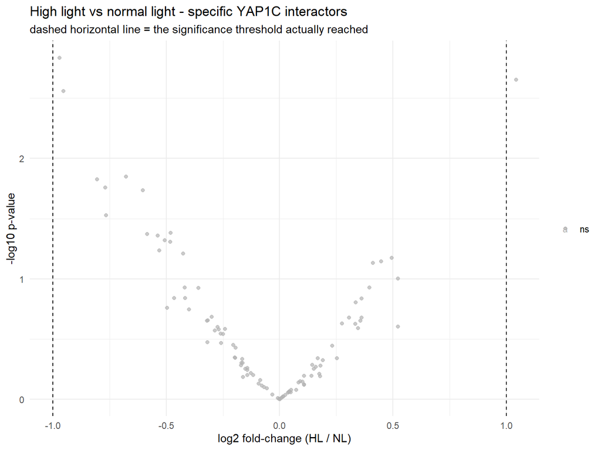

```r
sig_line <- if (any(de$direction != "ns"))
  -log10(max(de$pvalue[de$direction != "ns"], na.rm = TRUE)) else NA_real_

ggplot(de, aes(log2FC_HL_vs_NL, -log10(pvalue), colour = direction)) +
  geom_point(alpha = 0.7) +
  geom_vline(xintercept = c(-1, 1) * params$log2fc, linetype = "dashed") +
  { if (!is.na(sig_line))
      geom_hline(yintercept = sig_line, linetype = "dashed", colour = "grey40") } +
  ggrepel::geom_text_repel(data = filter(de, direction != "ns"),
                           aes(label = pep_label(Protein.Group)),
                           size = 3, max.overlaps = 20) +
  scale_colour_manual(values = c("up in HL" = "#c0392b",
                                 "down in HL" = "#2471a3", "ns" = "grey70")) +
  labs(title = "High light vs normal light - specific YAP1C interactors",
       subtitle = "dashed horizontal line = the significance threshold actually reached",
       x = "log2 fold-change (HL / NL)", y = "-log10 p-value", colour = NULL) +
  theme_minimal()
```

# 13 Step 3, arm 2: HL vs NL by detection (Fisher’s exact test)

Covalent trapping by YAP1C behaves more like an **on/off** event near the detection limit than a graded fold-change, and in this kind of experiment the proteins that respond to high light are largely **gained or lost** rather than scaled up or down — exactly the proteins arm 1 cannot test. So this arm ignores intensity and tests **detection**: for each specific interactor, count how many of the 4 HL and 4 NL replicates identified it, and apply Fisher’s exact test to the 2 x 2 table.

Two descriptive labels come out of the same counts:

- **`detection_class`** — the raw on/off picture: `HL-only`, `NL-only` (seen at least once in one treatment, never in the other) or `shared`.
- **`pattern`** — how *reproducible* that is, using the 3/4 rule: `HL-exclusive`, `NL-exclusive` (reproducible in one treatment, absent from the other), `HL-biased`, `NL-biased` (reproducible in one, patchy in the other), `both treatments`, or `sparse` (never reproducible anywhere).

```r
n_rep_HL <- length(hl_runs); n_rep_NL <- length(nl_runs)

det_counts <- rep %>%
  filter(Genotype == "YAP1C", Protein.Group %in% specific$Protein.Group) %>%
  group_by(Protein.Group, Treatment) %>%
  summarise(n_det = n_distinct(Run), .groups = "drop")

pa <- specific %>% select(Protein.Group) %>%
  left_join(det_counts %>% filter(Treatment == "HL") %>%
              transmute(Protein.Group, det_HL = n_det), by = "Protein.Group") %>%
  left_join(det_counts %>% filter(Treatment == "NL") %>%
              transmute(Protein.Group, det_NL = n_det), by = "Protein.Group") %>%
  mutate(det_HL = replace_na(det_HL, 0L), det_NL = replace_na(det_NL, 0L),
         detection_class = case_when(det_HL > 0 & det_NL == 0 ~ "HL-only",
                                     det_NL > 0 & det_HL == 0 ~ "NL-only",
                                     TRUE                     ~ "shared"),
         pattern = case_when(
           det_HL >= params$min_reps & det_NL == 0               ~ "HL-exclusive",
           det_NL >= params$min_reps & det_HL == 0               ~ "NL-exclusive",
           det_HL >= params$min_reps & det_NL <  params$min_reps ~ "HL-biased",
           det_NL >= params$min_reps & det_HL <  params$min_reps ~ "NL-biased",
           det_HL >= params$min_reps & det_NL >= params$min_reps ~ "both treatments",
           TRUE                                                  ~ "sparse"),
         # the coarse grouping used by the specificity bar chart and the GO analysis
         specificity = case_when(
           pattern %in% c("HL-exclusive", "HL-biased") ~ "HL-specific",
           pattern %in% c("NL-exclusive", "NL-biased") ~ "NL-specific",
           pattern == "both treatments"                ~ "both treatments",
           TRUE                                        ~ "sparse"),
         fisher_p = mapply(function(a, b)
           fisher.test(matrix(c(a, n_rep_HL - a, b, n_rep_NL - b), nrow = 2))$p.value,
           det_HL, det_NL),
         fisher_adj = p.adjust(fisher_p, "BH"),
         pa_direction = case_when(
           fisher_adj < params$fdr & det_HL > det_NL ~ "more in HL",
           fisher_adj < params$fdr & det_NL > det_HL ~ "more in NL",
           TRUE                                      ~ "ns"),
         tested_by_intensity = Protein.Group %in% rownames(X)) %>%
  arrange(fisher_p, desc(abs(det_HL - det_NL)))

write_csv(pa %>% left_join(specific, by = "Protein.Group"),
          file.path(params$outdir, "YAP1C_NL_vs_HL_presence_absence.csv"))
write_csv(pa %>% filter(!tested_by_intensity) %>% left_join(specific, by = "Protein.Group"),
          file.path(params$outdir, "YAP1C_condition_exclusive.csv"))

cat("Detection pattern by route into the specific set:\n")
```

```
## Detection pattern by route into the specific set:
```

```r
print(table(route   = specific$route[match(pa$Protein.Group, specific$Protein.Group)],
            pattern = pa$pattern))
```

```
##                         pattern
## route                    both treatments HL-biased HL-exclusive NL-biased
##   A: absent from YAP1A                61        77           28        15
##   B: enriched over YAP1A              38         0            0         0
##                         pattern
## route                    NL-exclusive
##   A: absent from YAP1A              3
##   B: enriched over YAP1A            0
```

```r
cat(sprintf("\nFisher test significant (adj.p < %.2g): %d  (more in HL = %d, more in NL = %d)\n",
            params$fdr, sum(pa$pa_direction != "ns"),
            sum(pa$pa_direction == "more in HL"), sum(pa$pa_direction == "more in NL")))
```

```
##
## Fisher test significant (adj.p < 0.05): 0  (more in HL = 0, more in NL = 0)
```

```r
pa %>% left_join(select(specific, Protein.Group, Genes, route), by = "Protein.Group") %>%
  head(20)
```

| Protein.Group | det_HL | det_NL | detection_class | pattern | specificity | fisher_p | fisher_adj | pa_direction | tested_by_intensity | Genes | route |
| --- | --- | --- | --- | --- | --- | --- | --- | --- | --- | --- | --- |
| F4I591;Q9SH55 | 4 | 0 | HL-only | HL-exclusive | HL-specific | 0.02857143 | 0.674772 | ns | FALSE | At1g64050 | A: absent from YAP1A |
| Q501D2 | 4 | 0 | HL-only | HL-exclusive | HL-specific | 0.02857143 | 0.674772 | ns | FALSE | IQD30 | A: absent from YAP1A |
| Q93W87 | 4 | 0 | HL-only | HL-exclusive | HL-specific | 0.02857143 | 0.674772 | ns | FALSE | At3g05760 | A: absent from YAP1A |
| Q94AG6 | 4 | 0 | HL-only | HL-exclusive | HL-specific | 0.02857143 | 0.674772 | ns | FALSE | SAMC1 | A: absent from YAP1A |
| Q9STM6 | 4 | 0 | HL-only | HL-exclusive | HL-specific | 0.02857143 | 0.674772 | ns | FALSE | At3g48460 | A: absent from YAP1A |
| A0A1I9LTL1;F4IW82 | 4 | 1 | shared | HL-biased | HL-specific | 0.14285714 | 0.674772 | ns | FALSE | CYP72A9 | A: absent from YAP1A |
| A0A1P8AS55;Q9SGU7 | 4 | 1 | shared | HL-biased | HL-specific | 0.14285714 | 0.674772 | ns | FALSE | At1g64680 | A: absent from YAP1A |
| F4HNZ9 | 3 | 0 | HL-only | HL-exclusive | HL-specific | 0.14285714 | 0.674772 | ns | FALSE | At1g12930 | A: absent from YAP1A |
| F4HVA6 | 3 | 0 | HL-only | HL-exclusive | HL-specific | 0.14285714 | 0.674772 | ns | FALSE | TAF6B | A: absent from YAP1A |
| F4HWC3 | 4 | 1 | shared | HL-biased | HL-specific | 0.14285714 | 0.674772 | ns | FALSE | At1g20970 | A: absent from YAP1A |

[output cut: 10 more lines]

## 13.1 Detection landscape

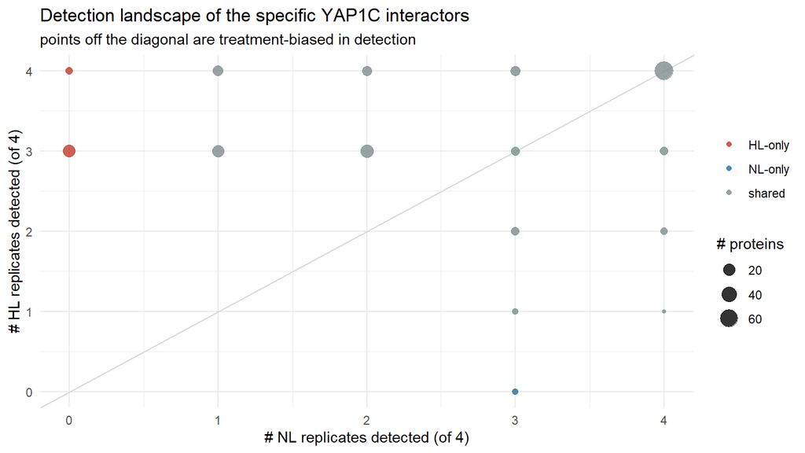

```r
ggplot(pa, aes(det_NL, det_HL)) +
  geom_abline(slope = 1, intercept = 0, colour = "grey85") +
  geom_count(aes(colour = detection_class), alpha = 0.8) +
  scale_x_continuous(breaks = 0:n_rep_NL) + scale_y_continuous(breaks = 0:n_rep_HL) +
  scale_colour_manual(values = c("HL-only" = "#c0392b",
                                 "NL-only" = "#2471a3", "shared" = "#7f8c8d")) +
  labs(title = "Detection landscape of the specific YAP1C interactors",
       subtitle = "points off the diagonal are treatment-biased in detection",
       x = sprintf("# NL replicates detected (of %d)", n_rep_NL),
       y = sprintf("# HL replicates detected (of %d)", n_rep_HL),
       size = "# proteins", colour = NULL) +
  theme_minimal()
```

## 13.2 Are they treatment-specific?

The same detection patterns, counted rather than plotted per protein. The bars split the broadened set into proteins reproducibly captured in **one** light condition only (treatment-specific, red for HL and blue for NL) and proteins captured in **both** (grey). Bars are also shown per route, so you can see whether the two definitions of specificity behave the same way.

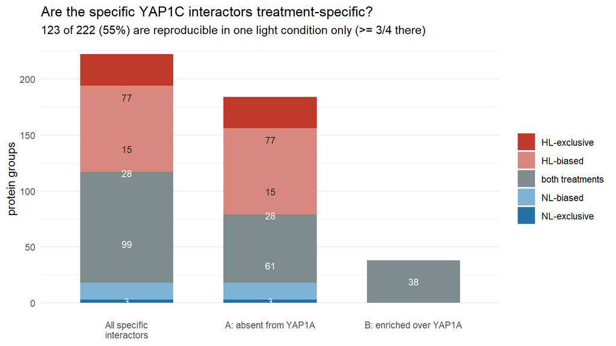

```r
# Classes come straight from the arm 2 detection patterns, so this figure and
# the tables above cannot disagree.
spec_levels <- c("HL-exclusive", "HL-biased", "both treatments",
                 "NL-biased", "NL-exclusive", "sparse")
spec_cols <- c("HL-exclusive" = "#c0392b", "HL-biased"    = "#d98880",
               "both treatments" = "#7f8c8d",
               "NL-biased"    = "#7fb3d5", "NL-exclusive" = "#2471a3",
               "sparse"       = "#d5dbdb")

ts <- pa %>%
  select(Protein.Group, pattern, specificity) %>%
  left_join(select(specific, Protein.Group, route), by = "Protein.Group") %>%
  mutate(pattern = factor(pattern, levels = spec_levels),
         treatment_specific = specificity %in% c("HL-specific", "NL-specific"))

# one bar per route, plus an "all interactors" bar for the set as a whole
all_label  <- "All specific\ninteractors"
ts_counts  <- bind_rows(mutate(ts, group = all_label), mutate(ts, group = route)) %>%
  group_by(group, pattern) %>%
  summarise(n = n(), .groups = "drop") %>%
  mutate(group = factor(group, levels = c(all_label, sort(unique(ts$route)))),
         # dark fills need white numbers, light fills need dark ones
         label_colour = ifelse(pattern %in% c("HL-biased", "NL-biased", "sparse"),
                               "grey15", "white"))

ggplot(ts_counts, aes(group, n, fill = pattern)) +
  geom_col(width = 0.65) +
  geom_text(aes(label = n, colour = label_colour), size = 3,
            position = position_stack(vjust = 0.5), show.legend = FALSE) +
  scale_fill_manual(values = spec_cols, name = NULL) +
  scale_colour_identity() +
  labs(title = "Are the specific YAP1C interactors treatment-specific?",
       subtitle = sprintf("%d of %d (%.0f%%) are reproducible in one light condition only (>= %d/4 there)",
                          sum(ts$treatment_specific), nrow(ts),
                          100 * mean(ts$treatment_specific), params$min_reps),
       x = NULL, y = "protein groups") +
  theme_minimal() +
  theme(panel.grid.major.x = element_blank())
```

```r
# the numbers behind the figure
ts %>% group_by(route) %>%
  summarise(n_interactors        = n(),
            n_treatment_specific = sum(treatment_specific),
            percent_specific     = round(100 * n_treatment_specific / n_interactors, 1),
            .groups = "drop")
```

| route | n_interactors | n_treatment_specific | percent_specific |
| --- | --- | --- | --- |
| A: absent from YAP1A | 184 | 123 | 66.8 |
| B: enriched over YAP1A | 38 | 0 | 0.0 |

# 14 Test coverage: which arm reached which protein

Before reading any verdict it is worth knowing which proteins each arm could actually say something about, because the two arms have **different entry requirements** and use slightly different evidence:

- **Arm 1 (intensity)** needs a MaxLFQ *number* in >= 3 of the 4 replicates of **each** treatment. A protein quantified in only one treatment cannot be fitted, and one identified but never quantified is invisible to this arm (and to every heatmap) altogether.
- **Arm 2 (detection)** only needs replicate *identification* counts, so it reaches almost everything. Identification and quantification are not the same thing — a run can identify a protein and still report no MaxLFQ value — which is a common reason for dropping out of arm 1 while staying in arm 2.

`tested_in` therefore takes four values: `both arms`, `intensity only`, `detection only`, and `neither`. A protein counts as tested by arm 2 if its 2 x 2 table contains at least one YAP1C identification; where HL and NL counts are **equal** the test still runs and returns p = 1, which is a real answer (“no detection difference”), not a failure — the `detection_informative` column flags those so they are not over-read. `neither` means no result came out of either arm, and those proteins are written to their own CSV with the reason spelled out. Given how the specific set is built this should be empty; the code checks rather than assumes.

```r
# n_HL / n_NL are the arm 1 inputs: how many YAP1C runs carry a MaxLFQ number.
quant_counts <- tibble(Protein.Group = rownames(log2mat),
                       n_quant_HL = unname(n_HL), n_quant_NL = unname(n_NL))

coverage <- specific %>%
  select(Protein.Group, ensembl_peptide_id, Genes, Protein.Names,
         any_of("Description"), route, qualifies_in, passes_step1) %>%
  left_join(quant_counts, by = "Protein.Group") %>%
  left_join(select(pa, Protein.Group, det_HL, det_NL, pattern, fisher_p),
            by = "Protein.Group") %>%
  left_join(select(de, Protein.Group, adj_pvalue), by = "Protein.Group") %>%
  mutate(
    n_quant_HL = replace_na(n_quant_HL, 0),
    n_quant_NL = replace_na(n_quant_NL, 0),
    in_quant_matrix = Protein.Group %in% rownames(log2mat),
    tested_by_intensity = !is.na(adj_pvalue),                      # limma fitted it
    tested_by_detection = !is.na(fisher_p) & (det_HL + det_NL) > 0,# a non-empty 2x2 table
    # equal HL and NL counts give p = 1 whatever the biology, so flag them
    detection_informative = tested_by_detection & det_HL != det_NL,
    tested_in = case_when(
      tested_by_intensity & tested_by_detection ~ "both arms",
      tested_by_intensity                       ~ "intensity only",
      tested_by_detection                       ~ "detection only",
      TRUE                                      ~ "neither"),
    why_not_tested = case_when(
      tested_in != "neither"                  ~ NA_character_,
      is.na(det_HL) | is.na(det_NL)           ~ "no detection counts - unexpected, check the report",
      det_HL + det_NL == 0 & !in_quant_matrix ~ "never identified and never quantified in any YAP1C run",
      det_HL + det_NL == 0                    ~ "never identified in any YAP1C run",
      TRUE                                    ~ "not fitted by arm 1 and no usable detection table")) %>%
  select(-adj_pvalue, -fisher_p) %>%
  arrange(factor(tested_in, levels = c("neither", "detection only",
                                       "intensity only", "both arms")), Genes)

write_csv(coverage, file.path(params$outdir, "YAP1C_NL_vs_HL_test_coverage.csv"))

untested <- filter(coverage, tested_in == "neither")
write_csv(untested, file.path(params$outdir, "YAP1C_NL_vs_HL_untested.csv"))

cat("Coverage of the", nrow(coverage), "specific interactors, by route:\n")
```

```
## Coverage of the 222 specific interactors, by route:
```

```r
print(table(route = coverage$route, tested_in = coverage$tested_in))
```

```
##                         tested_in
## route                    both arms detection only
##   A: absent from YAP1A          61            123
##   B: enriched over YAP1A        38              0
```

```r
cat("\nTested by NEITHER arm:", nrow(untested), "\n")
```

```
##
## Tested by NEITHER arm: 0
```

```r
cat("Not fitted by arm 1, so relying on the detection answer alone:",
    sum(!coverage$tested_by_intensity), "\n")
```

```
## Not fitted by arm 1, so relying on the detection answer alone: 123
```

```r
cat("Identified but never quantified (invisible to arm 1 and to every heatmap):",
    sum(!coverage$in_quant_matrix), "\n")
```

```
## Identified but never quantified (invisible to arm 1 and to every heatmap): 0
```

```r
cat("Equal HL and NL detection counts, so arm 2 can only return p = 1:",
    sum(coverage$det_HL == coverage$det_NL, na.rm = TRUE), "\n")
```

```
## Equal HL and NL detection counts, so arm 2 can only return p = 1: 79
```

```r
if (nrow(untested)) {
  print(table(untested$why_not_tested))
  untested %>% select(Protein.Group, Genes, route, n_quant_HL, n_quant_NL,
                      det_HL, det_NL, why_not_tested) %>% head(30)
} else {
  cat("\n-> every specific interactor was reached by at least one arm.",
      "\n   YAP1C_NL_vs_HL_untested.csv is written with headers and no rows.\n")
}
```

```
##
## -> every specific interactor was reached by at least one arm.
##    YAP1C_NL_vs_HL_untested.csv is written with headers and no rows.
```

# 15 Step 4: one verdict per protein

Each specific interactor gets a single answer: the **intensity** result where the protein was testable in both treatments, otherwise the **detection** result. Two columns keep the reading honest: `route` records how the protein earned its place in the specific set, so you can check whether the two routes tell the same story, and `tested_in` records which arm could reach it. Proteins neither arm could test are labelled **`not testable (no HL/NL information)`** rather than `no clear NL/HL difference` — an absence of evidence, not evidence of absence.

```r
verdict_levels <- c("HL-enriched (quant)", "HL-gained (presence)", "HL-leaning (detection)",
                    "NL-enriched (quant)", "NL-gained (presence)", "NL-leaning (detection)",
                    "no clear NL/HL difference", "not testable (no HL/NL information)")

combined <- specific %>%
  select(Protein.Group, ensembl_peptide_id, Genes, Protein.Names,
         any_of("Description"), route, qualifies_in) %>%
  left_join(select(coverage, Protein.Group, tested_in, in_quant_matrix,
                   n_quant_HL, n_quant_NL), by = "Protein.Group") %>%
  left_join(select(pa, Protein.Group, det_HL, det_NL, detection_class, pattern,
                   fisher_p, fisher_adj, pa_direction), by = "Protein.Group") %>%
  left_join(select(de, Protein.Group, log2FC_HL_vs_NL, pvalue, adj_pvalue, direction),
            by = "Protein.Group") %>%
  mutate(tested_by_intensity = !is.na(adj_pvalue),
         verdict = case_when(
           tested_by_intensity & direction == "up in HL"   ~ "HL-enriched (quant)",
           tested_by_intensity & direction == "down in HL" ~ "NL-enriched (quant)",
           pa_direction == "more in HL"                    ~ "HL-gained (presence)",
           pa_direction == "more in NL"                    ~ "NL-gained (presence)",
           detection_class == "HL-only"                    ~ "HL-leaning (detection)",
           detection_class == "NL-only"                    ~ "NL-leaning (detection)",
           # separated from the line below on purpose: "no test was possible" is
           # not the same statement as "we tested and found no difference"
           tested_in == "neither"       ~ "not testable (no HL/NL information)",
           TRUE                         ~ "no clear NL/HL difference")) %>%
  arrange(factor(verdict, levels = verdict_levels), coalesce(adj_pvalue, fisher_adj))

write_csv(combined, file.path(params$outdir, "YAP1C_NL_vs_HL_combined_verdict.csv"))

cat("Verdict by route into the specific set:\n")
```

```
## Verdict by route into the specific set:
```

```r
print(table(verdict = factor(combined$verdict, levels = verdict_levels),
            route   = combined$route))
```

```
##                                      route
## verdict                               A: absent from YAP1A
##   HL-enriched (quant)                                    0
##   HL-gained (presence)                                   0
##   HL-leaning (detection)                                28
##   NL-enriched (quant)                                    0
##   NL-gained (presence)                                   0
##   NL-leaning (detection)                                 3
##   no clear NL/HL difference                            153
##   not testable (no HL/NL information)                    0
##                                      route
## verdict                               B: enriched over YAP1A
##   HL-enriched (quant)                                      0
##   HL-gained (presence)                                     0
##   HL-leaning (detection)                                   0
##   NL-enriched (quant)                                      0
##   NL-gained (presence)                                     0
##   NL-leaning (detection)                                   0
##   no clear NL/HL difference                               38
##   not testable (no HL/NL information)                      0
```

```r
combined %>% filter(!verdict %in% c("no clear NL/HL difference",
                                    "not testable (no HL/NL information)")) %>% head(30)
```

| Protein.Group | ensembl_peptide_id | Genes | Protein.Names | Description | route | qualifies_in | tested_in | in_quant_matrix | n_quant_HL | n_quant_NL | det_HL | det_NL | detection_class | pattern | fisher_p | fisher_adj | pa_direction | log2FC_HL_vs_NL | pvalue | adj_pvalue | direction | tested_by_intensity | verdict |
| --- | --- | --- | --- | --- | --- | --- | --- | --- | --- | --- | --- | --- | --- | --- | --- | --- | --- | --- | --- | --- | --- | --- | --- |
| F4HNZ9 | AT1G12930.1 | At1g12930 | F4HNZ9_ARATH | ARM repeat superfamily protein | A: absent from YAP1A | HL | detection only | TRUE | 3 | 0 | 3 | 0 | HL-only | HL-exclusive | 0.14285714 | 0.674772 | ns | NA | NA | NA | NA | FALSE | HL-leaning (detection) |
| F4HVA6 | F4HVA6 | TAF6B | TAF6B_ARATH | Transcription initiation factor TFIID subunit 6b | A: absent from YAP1A | HL | detection only | TRUE | 3 | 0 | 3 | 0 | HL-only | HL-exclusive | 0.14285714 | 0.674772 | ns | NA | NA | NA | NA | FALSE | HL-leaning (detection) |
| F4I456;Q940R2 | AT1G04130.1;AT1G04130.2 | TPR2 | F4I456_ARATH;Q940R2_ARATH | Tetratricopeptide repeat (TPR)-like superfamily protein | A: absent from YAP1A | HL | detection only | TRUE | 3 | 0 | 3 | 0 | HL-only | HL-exclusive | 0.14285714 | 0.674772 | ns | NA | NA | NA | NA | FALSE | HL-leaning (detection) |
| F4I591;Q9SH55 | AT1G64050.2;AT1G64050.1 | At1g64050 | F4I591_ARATH;Q9SH55_ARATH | Uncharacterized protein | A: absent from YAP1A | HL | detection only | TRUE | 4 | 0 | 4 | 0 | HL-only | HL-exclusive | 0.02857143 | 0.674772 | ns | NA | NA | NA | NA | FALSE | HL-leaning (detection) |
| F4K465 | AT5G20200.1 | At5g20200 | F4K465_ARATH | Nucleoporin-like protein | A: absent from YAP1A | HL | detection only | TRUE | 3 | 0 | 3 | 0 | HL-only | HL-exclusive | 0.14285714 | 0.674772 | ns | NA | NA | NA | NA | FALSE | HL-leaning (detection) |
| O04647 | AT5G27270.1 | EMB976 | PP399_ARATH | Pentatricopeptide repeat-containing protein At5g27270 | A: absent from YAP1A | HL | detection only | TRUE | 3 | 0 | 3 | 0 | HL-only | HL-exclusive | 0.14285714 | 0.674772 | ns | NA | NA | NA | NA | FALSE | HL-leaning (detection) |
| O23066 | AT4G00360.1 | CYP86A2 | C86A2_ARATH | Cytochrome P450 86A2 | A: absent from YAP1A | HL | detection only | TRUE | 3 | 0 | 3 | 0 | HL-only | HL-exclusive | 0.14285714 | 0.674772 | ns | NA | NA | NA | NA | FALSE | HL-leaning (detection) |
| O64587 | AT2G34690.1 | ACD11 | ACD11_ARATH | Accelerated cell death 11 | A: absent from YAP1A | HL | detection only | TRUE | 3 | 0 | 3 | 0 | HL-only | HL-exclusive | 0.14285714 | 0.674772 | ns | NA | NA | NA | NA | FALSE | HL-leaning (detection) |
| Q37165 | ATCG01100.1 | ndhA | NU1C_ARATH | NAD(P)H-quinone oxidoreductase subunit 1, chloroplastic | A: absent from YAP1A | HL | detection only | TRUE | 3 | 0 | 3 | 0 | HL-only | HL-exclusive | 0.14285714 | 0.674772 | ns | NA | NA | NA | NA | FALSE | HL-leaning (detection) |
| Q501D2 | AT1G18840.2 | IQD30 | IQD30_ARATH | Protein IQ-DOMAIN 30 | A: absent from YAP1A | HL | detection only | TRUE | 4 | 0 | 4 | 0 | HL-only | HL-exclusive | 0.02857143 | 0.674772 | ns | NA | NA | NA | NA | FALSE | HL-leaning (detection) |

[output cut: 20 more lines]

# 16 Heatmaps

All three heatmaps show **absolute log2 PG.MaxLFQ** (not z-scored) across the eight YAP1C runs, NL block beside HL block, so intensities can be compared directly. Cells that were never quantified stay **grey**, which is what makes on/off behaviour visible.

## 16.1 Condition-biased interactors

Reproducible (>= 3/4) in one treatment but not the other.

```r
biased <- filter(pa, pattern %in% c("HL-exclusive", "NL-exclusive",
                                    "HL-biased", "NL-biased"))
cat("Condition-biased interactors:", nrow(biased), "\n"); print(table(biased$pattern))
```

```
## Condition-biased interactors: 123
```

```
##
##    HL-biased HL-exclusive    NL-biased NL-exclusive
##           77           28           15            3
```

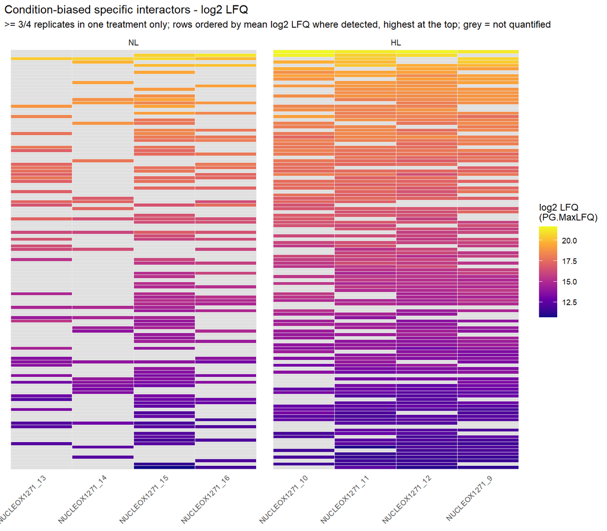

```r
lfq_heatmap(order_by_mean_lfq(biased$Protein.Group, log2mat),
            mat = log2mat,
            title = "Condition-biased specific interactors - log2 LFQ",
            subtitle = sprintf(">= %d/4 replicates in one treatment only; rows ordered by mean log2 LFQ where detected, highest at the top; grey = not quantified",
                               params$min_reps))
```

## 16.2 Treatment-exclusive interactors

The strict on/off cases: reproducible in one treatment, **never** seen in the other. One block is entirely grey by construction, so rows are grouped by class and ordered by mean intensity rather than by HL - NL.

```r
exclusive <- filter(pa, pattern %in% c("HL-exclusive", "NL-exclusive"))
cat("Treatment-exclusive interactors:", nrow(exclusive), "\n")
```

```
## Treatment-exclusive interactors: 31
```

```r
print(table(exclusive$pattern))
```

```
##
## HL-exclusive NL-exclusive
##           28            3
```

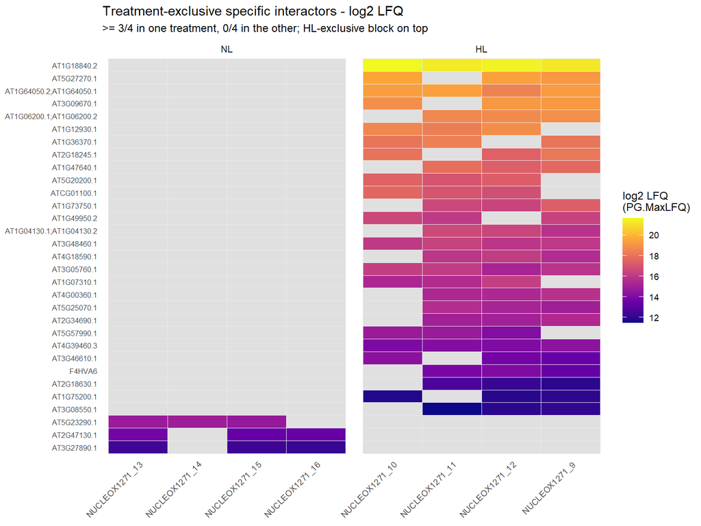

```r
# Each class kept as a block, and within a block the most abundant first.
ex_pg <- c(order_by_mean_lfq(exclusive$Protein.Group[exclusive$pattern == "HL-exclusive"],
                             log2mat),
           order_by_mean_lfq(exclusive$Protein.Group[exclusive$pattern == "NL-exclusive"],
                             log2mat))

lfq_heatmap(ex_pg, mat = log2mat,
            title = "Treatment-exclusive specific interactors - log2 LFQ",
            subtitle = sprintf(">= %d/4 in one treatment, 0/4 in the other; HL-exclusive block on top",
                               params$min_reps))
```

## 16.3 Every specific interactor

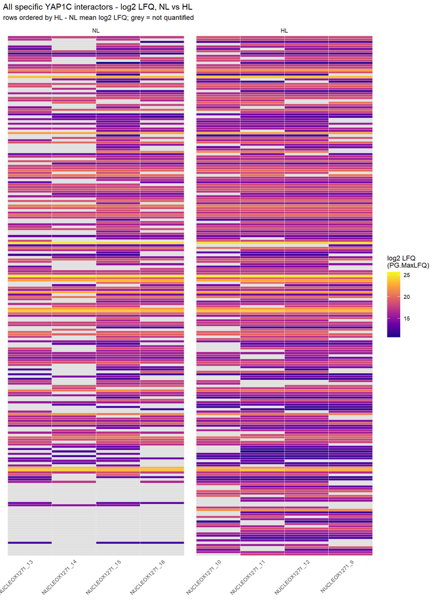

```r
lfq_heatmap(order_by_hl_minus_nl(rownames(log2mat), log2mat, hl_runs, nl_runs),
            mat = log2mat,
            title = "All specific YAP1C interactors - log2 LFQ, NL vs HL",
            subtitle = "rows ordered by HL - NL mean log2 LFQ; grey = not quantified")
```

# 17 GO term enrichment

Which biological functions are over-represented among the specific YAP1C interactors — and do the HL-specific and NL-specific proteins do different jobs?

**The background matters more than the test.** The comparison set here is **every protein group identified in this experiment**, not every gene in the genome. A pull-down only sees abundant, extractable, MS-friendly proteins, so testing against the whole genome mostly rediscovers that fact and returns “ribosome”, “chloroplast”, “cytosol” no matter what the bait was. Against the detected background, a term is only enriched if it stands out among proteins the experiment could have seen.

Annotations come from **`org.At.tair.db`**, the Bioconductor annotation package for Arabidopsis. It is keyed on TAIR loci, which is exactly what the protein groups map to, and it works offline once installed — no web service to time out mid-knit. One locus is used per protein group (the first mapped accession). Annotations are then **propagated up the GO hierarchy** with `GO.db`: a protein annotated to *response to hydrogen peroxide* is by definition also annotated to *response to oxidative stress*, and without propagation those broader categories would be badly under-counted.

```r
# GO annotations come from org.At.tair.db, the Bioconductor annotation package
# for Arabidopsis. It is keyed on TAIR loci - exactly what the protein groups
# map to - and works offline once installed, so there is no web service to fail.
for (pkg in c("GO.db", "org.At.tair.db")) {
  if (!requireNamespace(pkg, quietly = TRUE)) {
    if (!requireNamespace("BiocManager", quietly = TRUE))
      install.packages("BiocManager", repos = "https://cloud.r-project.org")
    BiocManager::install(pkg, update = FALSE, ask = FALSE)
  }
}

# --- 1. protein group -> TAIR locus --------------------------------------
# AT3G14630.2 -> AT3G14630. Groups whose ID fell back to a UniProt accession
# have no locus and drop out here.
pg2gene <- annot %>%
  transmute(Protein.Group,
            gene = toupper(sub("\\.\\d+$", "", sub(";.*$", "", ensembl_peptide_id)))) %>%
  filter(grepl("^AT[1-5CM]G[0-9]{5}$", gene))

cat(sprintf("Protein groups with a TAIR locus: %d of %d\n",
            nrow(pg2gene), nrow(annot)))
```

```
## Protein groups with a TAIR locus: 5111 of 5170
```

```r
# --- 2. TAIR locus -> GO term --------------------------------------------
# Only ask about loci the package recognises: select() errors outright if none
# of the keys are valid, and warns confusingly if some are not.
known_keys <- AnnotationDbi::keys(org.At.tair.db::org.At.tair.db, keytype = "TAIR")
go_keys    <- intersect(unique(pg2gene$gene), known_keys)

g2go <- if (length(go_keys)) {
  suppressMessages(
    AnnotationDbi::select(org.At.tair.db::org.At.tair.db, keys = go_keys,
                          columns = "GO", keytype = "TAIR")) %>%
    filter(!is.na(GO)) %>%
    distinct(gene = TAIR, go_id = GO)
} else {
  tibble(gene = character(), go_id = character())
}

cat(sprintf("Loci recognised by org.At.tair.db: %d of %d\n",
            length(go_keys), n_distinct(pg2gene$gene)))
```

```
## Loci recognised by org.At.tair.db: 5106 of 5109
```

```r
cat(sprintf("Direct gene-to-term annotations: %d\n", nrow(g2go)))
```

```
## Direct gene-to-term annotations: 39898
```

```r
# go_ok gates the chunks below, so a GO problem costs you this section and
# nothing else - the rest of the report still knits.
go_ok <- nrow(pg2gene) > 0 && nrow(g2go) > 0
if (!go_ok) cat(
  "\n!! GO section skipped. Check the counts above: if no protein group got a\n",
  "   TAIR locus, the peptide-ID mapping upstream is what needs fixing; if loci\n",
  "   were found but no annotations came back, reinstall org.At.tair.db.\n")
```

```r
# Propagate each annotation up the GO hierarchy: a protein annotated to
# "response to hydrogen peroxide" also counts towards "response to oxidative
# stress". Without this, broad categories are badly under-counted.
ancestors <- c(as.list(GO.db::GOBPANCESTOR),
               as.list(GO.db::GOMFANCESTOR),
               as.list(GO.db::GOCCANCESTOR))
per_gene <- lapply(split(g2go$go_id, g2go$gene), function(ids)
  setdiff(unique(c(ids, unlist(ancestors[ids], use.names = FALSE))), c("all", NA)))

# as.character() keeps both columns character even if a list comes back empty;
# without it an empty result produces NULL columns and the lookup below fails
# with "'keys' must be a character vector".
go_prop <- tibble(gene  = toupper(as.character(rep(names(per_gene), lengths(per_gene)))),
                  go_id = as.character(unlist(per_gene, use.names = FALSE)))

go_info <- suppressMessages(
  AnnotationDbi::select(GO.db::GO.db, keys = unique(go_prop$go_id),
                        columns = c("TERM", "ONTOLOGY"), keytype = "GOID")) %>%
  filter(!is.na(TERM))

cat(sprintf("After propagation: %d genes, %d distinct GO terms\n",
            n_distinct(go_prop$gene), n_distinct(go_prop$go_id)))
```

```
## After propagation: 5106 genes, 6899 distinct GO terms
```

**The test.** For each GO term: of the *B* background genes, *b* carry the term; of the *Q* genes in the list being tested, *q* carry it. The hypergeometric p-value asks how surprising *q* is, and fold enrichment is `(q/Q) / (b/B)`. Terms are only tested if they cover at least 5 and at most 2000 background genes (tiny terms are noise, enormous ones are uninformative) and if the list contributes at least 3 genes. p-values are BH-adjusted **within each list**.

```r
# The background is the genes that are BOTH measurable here and GO-annotated.
universe   <- intersect(unique(pg2gene$gene), unique(go_prop$gene))
go_bg      <- filter(go_prop, gene %in% universe)
n_universe <- length(universe)

cat(sprintf("Genes from protein groups: %d | genes with GO: %d | background overlap: %d\n",
            n_distinct(pg2gene$gene), n_distinct(go_prop$gene), n_universe))
```

```
## Genes from protein groups: 5109 | genes with GO: 5106 | background overlap: 5106
```

```r
if (!n_universe)
  cat("!! The two ID sets do not overlap, so nothing can be tested. Examples:\n",
      "   from protein groups:",
      paste(head(unique(pg2gene$gene), 5), collapse = ", "), "\n",
      "   from Ensembl GO    :",
      paste(head(unique(go_prop$gene), 5), collapse = ", "), "\n",
      "   If those are different kinds of identifier, the locus mapping in the\n",
      "   chunk above is what needs fixing.\n")

term_sizes <- go_bg %>%
  group_by(go_id) %>% summarise(n_bg = n(), .groups = "drop") %>%
  filter(n_bg >= 5, n_bg <= 2000)

# Hypergeometric over-representation of one gene list against that background.
# The empty case must carry the same columns as the full one: bind_rows() of
# bare tibble()s gives a table with no columns at all, and the join below then
# fails with "Join columns in `x` must be present in the data".
empty_result <- tibble(go_id = character(), n_hit = integer(), n_bg = integer(),
                       list = character(), n_query = integer(),
                       fold_enrichment = double(), pvalue = double(),
                       adj_pvalue = double())

go_test <- function(genes, label) {
  q_genes <- intersect(unique(genes), universe)
  n_query <- length(q_genes)
  if (!n_query || !nrow(term_sizes)) return(empty_result)
  go_bg %>%
    filter(gene %in% q_genes) %>%
    group_by(go_id) %>% summarise(n_hit = n(), .groups = "drop") %>%
    inner_join(term_sizes, by = "go_id") %>%
    filter(n_hit >= 3) %>%
    mutate(list = label, n_query = n_query,
           fold_enrichment = (n_hit / n_query) / (n_bg / n_universe),
           pvalue = phyper(n_hit - 1, n_bg, n_universe - n_bg, n_query,
                           lower.tail = FALSE),
           adj_pvalue = p.adjust(pvalue, "BH"))
}

# The whole broadened set, then split by how it behaves between treatments.
gene_of <- function(pgs) pg2gene$gene[pg2gene$Protein.Group %in% pgs]
lists <- list(
  "All interactors" = gene_of(specific$Protein.Group),
  "HL-specific"     = gene_of(pa$Protein.Group[pa$specificity == "HL-specific"]),
  "NL-specific"     = gene_of(pa$Protein.Group[pa$specificity == "NL-specific"]),
  "Both treatments" = gene_of(pa$Protein.Group[pa$specificity == "both treatments"]))

go_res <- bind_rows(lapply(names(lists), function(l) go_test(lists[[l]], l))) %>%
  left_join(go_info, by = c("go_id" = "GOID")) %>%
  select(list, go_id, term = TERM, ontology = ONTOLOGY, n_hit, n_query, n_bg,
         fold_enrichment, pvalue, adj_pvalue) %>%
  arrange(list, adj_pvalue)

write_csv(go_res, file.path(params$outdir, "YAP1C_GO_enrichment.csv"))

if (!nrow(go_res))
  cat("!! No GO term could be tested - see the diagnostics above.\n")
cat("Background genes:", n_universe, "| terms tested:", nrow(term_sizes), "\n")
```

```
## Background genes: 5106 | terms tested: 2916
```

```r
cat("Genes per list:", paste(sprintf("%s = %d", names(lists),
                                     vapply(lists, function(g)
                                       length(intersect(unique(g), universe)),
                                       integer(1))), collapse = "; "), "\n")
```

```
## Genes per list: All interactors = 220; HL-specific = 104; NL-specific = 17; Both treatments = 99
```

```r
cat(sprintf("Terms significant at adj.p < %.2g:\n", params$fdr))
```

```
## Terms significant at adj.p < 0.05:
```

```r
print(table(list = go_res$list, significant = go_res$adj_pvalue < params$fdr))
```

```
##                  significant
## list              FALSE TRUE
##   All interactors   584   11
##   Both treatments   294   56
##   HL-specific       285    0
##   NL-specific        44    2
```

```r
go_res %>% filter(list == "All interactors", adj_pvalue < params$fdr) %>%
  mutate(fold_enrichment = round(fold_enrichment, 2)) %>% head(25)
```

| list | go_id | term | ontology | n_hit | n_query | n_bg | fold_enrichment | pvalue | adj_pvalue |
| --- | --- | --- | --- | --- | --- | --- | --- | --- | --- |
| All interactors | GO:0031072 | heat shock protein binding | MF | 7 | 220 | 28 | 5.80 | 0.0001366660 | 0.03443694 |
| All interactors | GO:0051084 | 'de novo' post-translational protein folding | BP | 7 | 220 | 29 | 5.60 | 0.0001736316 | 0.03443694 |
| All interactors | GO:0051085 | chaperone cofactor-dependent protein refolding | BP | 7 | 220 | 29 | 5.60 | 0.0001736316 | 0.03443694 |
| All interactors | GO:0000054 | ribosomal subunit export from nucleus | BP | 4 | 220 | 10 | 9.28 | 0.0005737275 | 0.04078026 |
| All interactors | GO:0000056 | ribosomal small subunit export from nucleus | BP | 3 | 220 | 5 | 13.93 | 0.0007399664 | 0.04078026 |
| All interactors | GO:0006458 | 'de novo' protein folding | BP | 7 | 220 | 33 | 4.92 | 0.0004101880 | 0.04078026 |
| All interactors | GO:0008379 | thioredoxin peroxidase activity | MF | 3 | 220 | 5 | 13.93 | 0.0007399664 | 0.04078026 |
| All interactors | GO:0009617 | response to bacterium | BP | 16 | 220 | 152 | 2.44 | 0.0007539208 | 0.04078026 |
| All interactors | GO:0033750 | ribosome localization | BP | 4 | 220 | 10 | 9.28 | 0.0005737275 | 0.04078026 |
| All interactors | GO:0034599 | cellular response to oxidative stress | BP | 7 | 220 | 34 | 4.78 | 0.0004978923 | 0.04078026 |

[output cut: 1 more lines]

## 17.1 GO heatmap

Rows are the strongest terms (up to 8 per list, grouped by ontology); columns are the four lists. Colour is the BH-adjusted p-value on a `-log10` scale, **capped at 10** so a single astronomically significant term does not flatten everything else. The number in each cell is how many proteins from that list carry the term. A **blank** cell means the term was not testable for that list (fewer than 3 of its proteins carry it), which is not the same as “not enriched”.

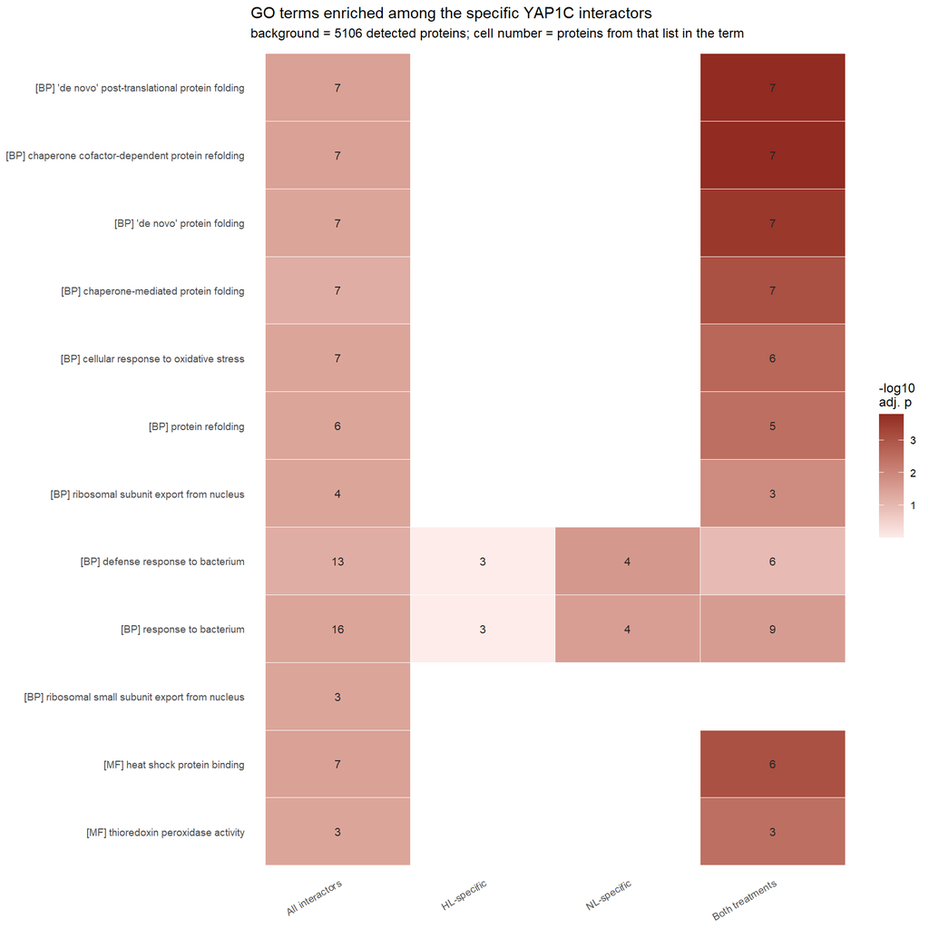

```r
top_terms <- go_res %>%
  filter(adj_pvalue < params$fdr) %>%
  group_by(list) %>% slice_min(adj_pvalue, n = 8, with_ties = FALSE) %>%
  ungroup() %>% distinct(go_id) %>% pull(go_id)

if (!length(top_terms)) {
  cat("No GO term reached adj.p <", params$fdr, "in any list - no heatmap drawn.\n")
} else {
  hm <- go_res %>%
    filter(go_id %in% top_terms) %>%
    mutate(row_label = sprintf("[%s] %s", ontology, str_trunc(term, 55)),
           list  = factor(list, levels = names(lists)),
           score = pmin(-log10(adj_pvalue), 10))

  row_order <- hm %>%
    group_by(row_label) %>%
    summarise(ontology = first(ontology), best = min(adj_pvalue), .groups = "drop") %>%
    arrange(ontology, best) %>% pull(row_label)

  ggplot(mutate(hm, row_label = factor(row_label, levels = rev(row_order))),
         aes(list, row_label, fill = score)) +
    geom_tile(colour = "white") +
    geom_text(aes(label = n_hit), size = 2.8, colour = "grey15") +
    scale_fill_gradient(low = "#fdecea", high = "#922b21",
                        name = "-log10\nadj. p") +
    labs(title = "GO terms enriched among the specific YAP1C interactors",
         subtitle = sprintf("background = %d detected proteins; cell number = proteins from that list in the term",
                            n_universe),
         x = NULL, y = NULL) +
    theme_minimal(base_size = 9) +
    theme(axis.text.x = element_text(angle = 30, hjust = 1),
          axis.text.y = element_text(size = 7),
          panel.grid = element_blank())
}
```

# 18 Files written

```r
list.files(params$outdir, full.names = TRUE)
```

```
##  [1] "output_batch1/results/uniprot_to_ensembl_peptide.csv"
##  [2] "output_batch1/results/unique_YAP1C_interactors.csv"
##  [3] "output_batch1/results/YAP1A_background_list.csv"
##  [4] "output_batch1/results/YAP1C_all_interactors.csv"
##  [5] "output_batch1/results/YAP1C_condition_exclusive.csv"
##  [6] "output_batch1/results/YAP1C_enriched_significant.csv"
##  [7] "output_batch1/results/YAP1C_GO_enrichment.csv"
##  [8] "output_batch1/results/YAP1C_NL_vs_HL_combined_verdict.csv"
##  [9] "output_batch1/results/YAP1C_NL_vs_HL_differential.csv"
## [10] "output_batch1/results/YAP1C_NL_vs_HL_presence_absence.csv"
## [11] "output_batch1/results/YAP1C_NL_vs_HL_test_coverage.csv"
## [12] "output_batch1/results/YAP1C_NL_vs_HL_untested.csv"
## [13] "output_batch1/results/YAP1C_specific_interactors_broadened.csv"
## [14] "output_batch1/results/YAP1C_vs_YAP1A_limma.csv"
```

**The two lists to work from**

- `YAP1C_specific_interactors_broadened.csv` — the specific interactor set (route A + route B), with a `route` column. This is what the HL vs NL analysis was run on.
- `YAP1C_NL_vs_HL_combined_verdict.csv` — one row per specific interactor with its final HL vs NL verdict, both tests side by side.
- `YAP1C_NL_vs_HL_test_coverage.csv` — which arm reached each protein (`tested_in`), with the identification and quantification counts behind that decision.
- `YAP1C_NL_vs_HL_untested.csv` — the proteins neither arm could test, each with a `why_not_tested` explanation. May well be empty; the notebook says so if it is.

**Supporting tables**

- `unique_YAP1C_interactors.csv` — route A only (absent from YAP1A).
- `YAP1C_enriched_significant.csv` — route B only (enriched over YAP1A).
- `YAP1A_background_list.csv` — protein groups called background.
- `YAP1C_all_interactors.csv` — interactors before any specificity filter.
- `YAP1C_vs_YAP1A_limma.csv` — the full probe-comparison test.
- `YAP1C_NL_vs_HL_differential.csv` — arm 1, intensity (limma).
- `YAP1C_NL_vs_HL_presence_absence.csv` — arm 2, detection (Fisher).
- `YAP1C_condition_exclusive.csv` — the proteins arm 1 could not test.
- `YAP1C_GO_enrichment.csv` — every GO term tested, per list, with fold enrichment and adjusted p-value.
- `uniprot_to_ensembl_peptide.csv` — cached Ensembl ID lookup. Delete it to force a fresh query.